# Assignment-2

Yizhe Qu

February 9, 2019

# Q1

```r
card <- read.csv("C:/Users/yizhe/Desktop/MDS/Term4/data_572/data/car93.csv", stringsAsFactors = FALSE)
pcard <- prcomp(as.matrix(card[,-c(1,2,3,4)]), scale.=TRUE)
summary(pcard)
```

```
## Importance of components:
##                          PC1    PC2     PC3     PC4     PC5     PC6
## Standard deviation     3.097 1.2112 0.94592 0.76113 0.59294 0.54436
## Proportion of Variance 0.685 0.1048 0.06391 0.04138 0.02511 0.02117
## Cumulative Proportion  0.685 0.7898 0.85374 0.89512 0.92023 0.94140
##                            PC7     PC8     PC9    PC10    PC11    PC12
## Standard deviation     0.48674 0.44913 0.34512 0.30099 0.26044 0.20876
## Proportion of Variance 0.01692 0.01441 0.00851 0.00647 0.00484 0.00311
## Cumulative Proportion  0.95832 0.97273 0.98124 0.98771 0.99255 0.99566
##                           PC13    PC14
## Standard deviation     0.19860 0.14579
## Proportion of Variance 0.00282 0.00152
## Cumulative Proportion  0.99848 1.00000
```

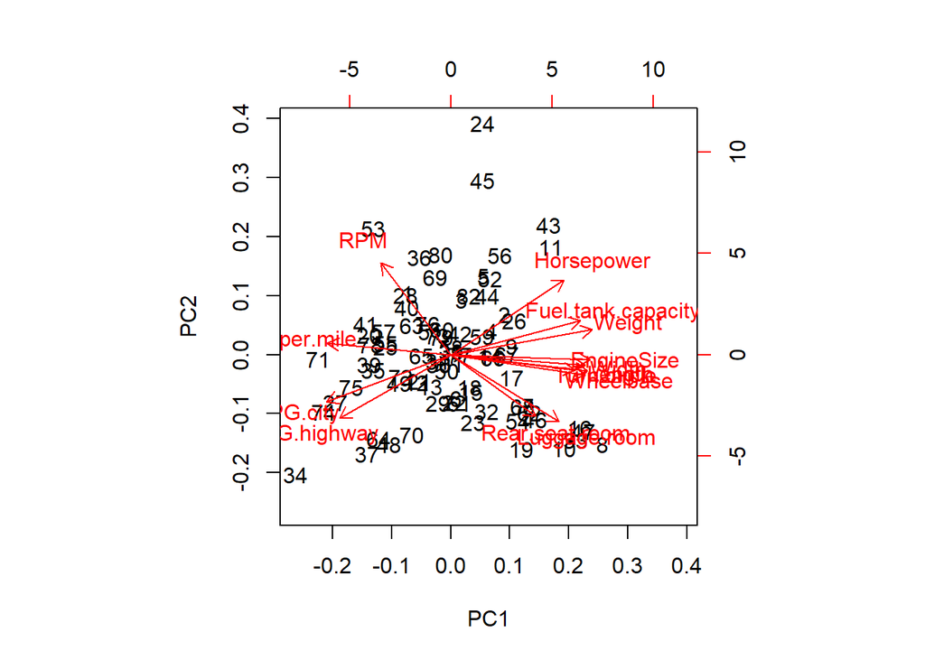

```r
biplot(pcard)
```

```r
cum_var <- cumsum(pcard$sdev^2/sum(pcard$sdev^2))
cum_var
```

```
##  [1] 0.6850394 0.7898256 0.8537371 0.8951171 0.9202301 0.9413967 0.9583193
##  [8] 0.9727279 0.9812358 0.9877069 0.9925517 0.9956646 0.9984818 1.0000000
```

3. According to scree plot, we keep the first two principal components since the “elbow” is found at PC2.

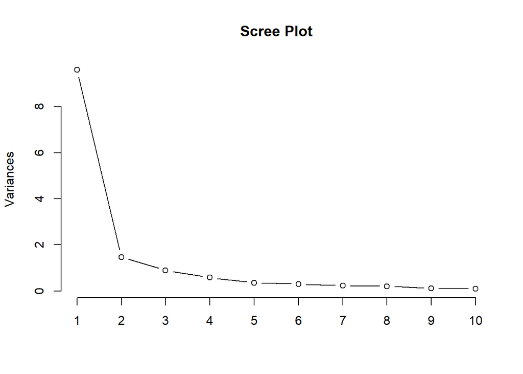

```r
plot(pcard, type="lines", main="Scree Plot")
```

```r
pccomps <- pcard$x[,1:2]
small <- card$Type=="Small"
cvres <- list()
predprob <- NA
for(i in 1:nrow(pccomps)){
  dum <- data.frame(small=small[-i], PC1=pccomps[-i,1], PC2=pccomps[-i,2])
  cvres[[i]] <- glm(small~., data=dum, family="binomial")
  predprob[i] <- predict(cvres[[i]], newdata=data.frame(pccomps), type="response")[i]
}
library(MLmetrics)
table(small, predprob>0.5)
```

```
##
## small   FALSE TRUE
##   FALSE    58    3
##   TRUE      4   17
```

```r
LogLoss(predprob, small)
```

```
## [1] 0.2496668
```

```r
library(MASS)
ldabin <- lda(small~pccomps, CV=TRUE)
table(small, ldabin$class)
```

```
##
## small   FALSE TRUE
##   FALSE    59    2
##   TRUE      4   17
```

```r
LogLoss(ldabin$posterior[,2], small)
```

```
## [1] 0.2224975
```

```r
ldamult <- lda(card$Type~pccomps, CV=TRUE)
table(card$Type, ldamult$class)
```

```
##
##           Compact Large Midsize Small Sporty
##   Compact      13     0       2     0      1
##   Large         0     9       2     0      0
##   Midsize       4     2      15     0      1
##   Small         2     0       0    16      3
##   Sporty        3     0       3     3      3
```

```r
MultiLogLoss(ldamult$posterior, card$Type)
```

```
## [1] 0.8001237
```

6. The fact that LDA and Logistic regression can find the structure of Small vs Not-Small cars in the first two fits suggests to some extent that our interpretation of the first component (size of car) may well hold true. In terms of LDA using all car types, we can see Compact, Small, Midsize, and Large all being largely distinguishable through the first two components. The only category of car that is poorly classified is Sporty.

# Q2

```r
library(nnet)
car_numeric <- card[,-c(1,2,3)]
scar <- apply(car_numeric, 2, function(v) (v-min(v))/(max(v)-min(v)))
set.seed(4521)
nncar <- nnet(Price~., data=scar, size=5)
res <- predict(nncar)
mse <- mean((scar[,1]-res)^2)
mse
```

```
## [1] 0.07963253
```

```r
set.seed(217)
ind <- sample(1:nrow(scar), 41)
train <- scar[ind,]
test <- scar[-ind,]
nncar <- nnet(Price~., data=train, size=5)
yhat <- predict(nncar, test[,-1])
mse <- mean((yhat-test[,1])^2)
mse
```

```
## [1] 0.01140137
```

Not marked (or bonus if the student notices the same thing and provides at least some further investigation): Note there is something funny going on here. In fact, our train test setup is providing better results than our original run on the full data.time for some investigation, after playing around with some settings, we can get.

```r
set.seed(4521)
nncar3 <- nnet(Price~., data=scar, size=2, maxit=3000, linout=TRUE, trace=FALSE)
res <- predict(nncar3)
mse <- mean((scar[,1]-res)^2)
mse
```

```
## [1] 0.001586173
```

```r
nncar4 <- nnet(Price~., data=train, size=2, maxit=3000, linout=TRUE, trace=FALSE)
yhat2 <- predict(nncar, test[,-1])
mse <- mean((yhat2-test[,1])^2)
mse
```

```
## [1] 0.01140137
```

Which makes more sense. I believe the predominant issue was the number of weights we were estimating given quite a small sample size (my apologies for setting up the question that way).

3. Now we first need to transfer back to the original scale, then to the dollars unit. I will provide the answer both in terms of sqrt(MSE) and MAE (mean absolute error), and I will use the original runs even though they don’t make much sense. Square root of the MSE does not provide you “on average, how far off is your model,” but the important practice I’m looking for in this question is transforming back to the original scale.

```r
#first get my predictions back to the original scale
osyhat <- yhat*(max(card$Price)-min(card$Price)) + min(card$Price)
#then to the dollars unit
osyhat <- 1000*osyhat
#then use the indexing for my testing set on the original price
osy <- card$Price[-ind]*1000
#now calculate sqrt(MSE) for this...
sqrt(mean((osyhat-osy)^2))
```

```
## [1] 5819.358
```

```r
#now for the better version
mean(abs(osyhat-osy))
```

```
## [1] 3589.563
```